# study1 preprocessing

anonymous

2024-12-10

```r
knit_by_pkgdown <- !is.null(knitr::opts_chunk$get("fig.retina"))
knitr::opts_chunk$set(
  warning = TRUE, # show warnings during codebook generation
  message = TRUE, # show messages during codebook generation
  error = TRUE, # do not interrupt codebook generation in case of errors,
                # TRUE is usually better for debugging
  echo = TRUE  # show R code
)

library(pacman)
pacman::p_load(tidyverse, here, codebook)
ggplot2::theme_set(ggplot2::theme_bw())
```

# 1 Read data

```r
base_path <- here("code", "study1")
data_path <- paste0(base_path, "/snapshots_study1_preprocessing_analysis/data_processed_step1.csv")
d <- read_csv(data_path) %>%
      mutate(
        subject_id = as.factor(subject_id),
        trial_type = as.factor(trial_type),
        trial_type_order = as.factor(trial_type_order),
        itemA = as.factor(itemA),
        itemB = as.factor(itemB),
        categoryA = as.factor(categoryA),
        categoryB = as.factor(categoryB)
      )
codebook::codebook(d)
```

### 1.0.1 Metadata

#### 1.0.1.1 Description

**Dataset name**: Processed data showing raw x y coordinates of Sorted items, and raw Causal ratings

**Metadata for search engines**

- **Date published**: 2025-02-03

| x |
| --- |
| subject_id |
| trial_type |
| trial_type_order |
| trial_index |
| question_index |
| response |
| itemA |
| itemB |
| categoryA |
| categoryB |
| attention_check |
| correct_response |
| original_trial_index |
| original_question_index |
| attention_check_id |
| correct |
| x |
| y |
| item |

## 1.1 Variables

### 1.1.1 subject_id

Subject ids for all 50 subjects

#### 1.1.1.1 Distribution

```
## 50  unique, categorical values, so not shown.
```

0 missing values.

#### 1.1.1.2 Summary statistics

| name | label | data_type | ordered | value_labels | n_missing | complete_rate | n_unique | top_counts |
| --- | --- | --- | --- | --- | --- | --- | --- | --- |
| subject_id | Subject ids for all 50 subjects | factor | FALSE | 1. subj_01, 2. subj_02, 3. subj_03, 4. subj_04, 5. subj_05, 6. subj_06, 7. subj_07, 8. subj_08, 9. subj_09, 10. subj_10, 11. subj_11, 12. subj_12, 13. subj_13, 14. subj_14, 15. subj_15, 16. subj_16, 1… | 0 | 1 | 50 | sub: 244, sub: 244, sub: 244, sub: 244 |

### 1.1.2 trial_type

Factor showing the two experimental conditions: Causal Task vs Sorting Task

#### 1.1.2.1 Distribution

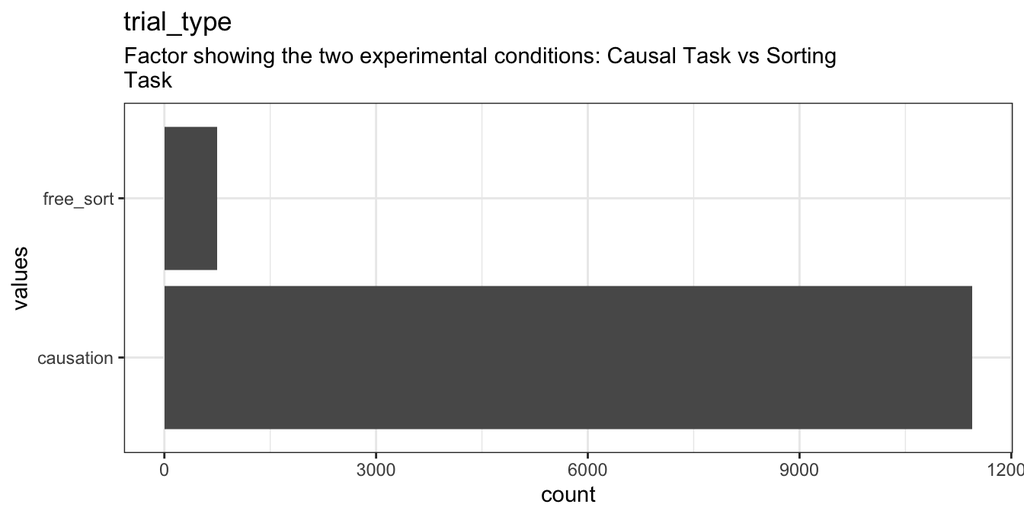

Distribution of values for trial_type

0 missing values.

#### 1.1.2.2 Summary statistics

| name | label | data_type | ordered | value_labels | n_missing | complete_rate | n_unique | top_counts |
| --- | --- | --- | --- | --- | --- | --- | --- | --- |
| trial_type | Factor showing the two experimental conditions: Causal Task vs Sorting Task | factor | FALSE | 1. causation, 2. free_sort | 0 | 1 | 2 | cau: 11450, fre: 750 |

### 1.1.3 trial_type_order

Factor showing the two experimental orders, Causal Task first or Sorting Task first

#### 1.1.3.1 Distribution

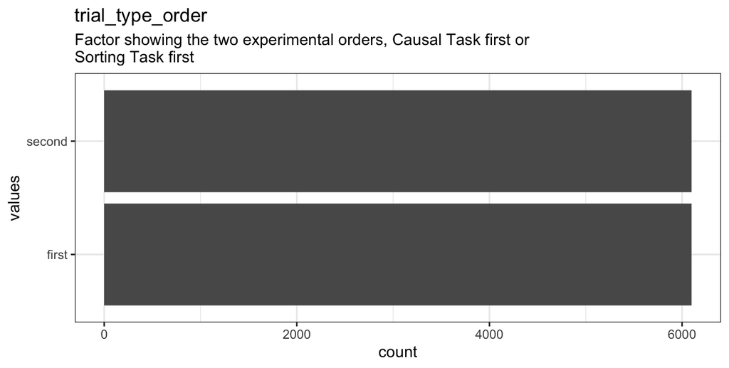

Distribution of values for trial_type_order

0 missing values.

#### 1.1.3.2 Summary statistics

| name | label | data_type | ordered | value_labels | n_missing | complete_rate | n_unique | top_counts |
| --- | --- | --- | --- | --- | --- | --- | --- | --- |
| trial_type_order | Factor showing the two experimental orders, Causal Task first or Sorting Task first | factor | FALSE | 1. first, 2. second | 0 | 1 | 2 | fir: 6100, sec: 6100 |

### 1.1.4 trial_index

Index indicating the page of the trial. Subjects had about 15 pages of trials

#### 1.1.4.1 Distribution

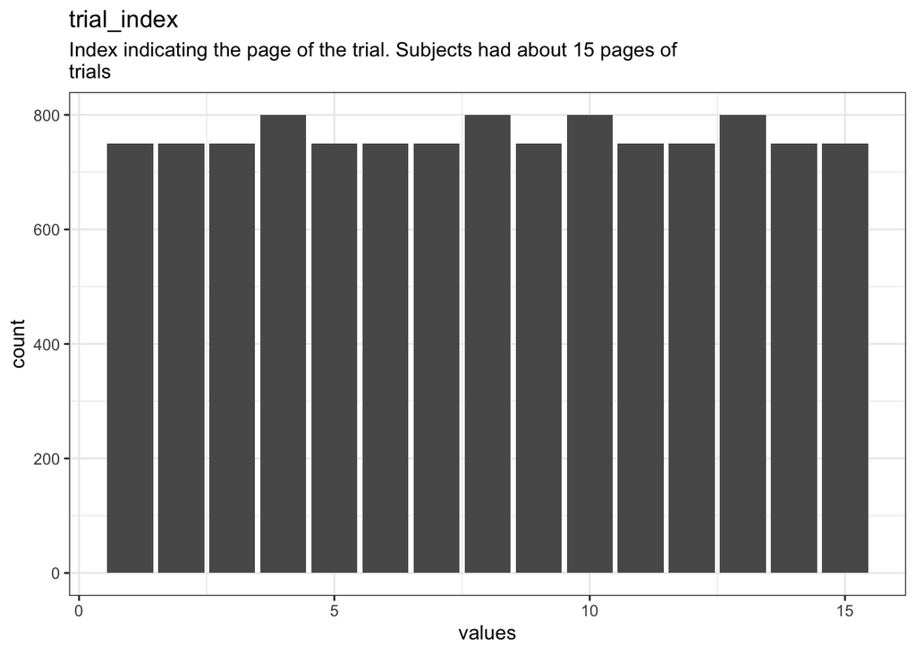

Distribution of values for trial_index

750 missing values.

#### 1.1.4.2 Summary statistics

| name | label | data_type | n_missing | complete_rate | min | median | max | mean | sd | hist |
| --- | --- | --- | --- | --- | --- | --- | --- | --- | --- | --- |
| trial_index | Index indicating the page of the trial. Subjects had about 15 pages of trials | numeric | 750 | 0.9385246 | 1 | 8 | 15 | 8.0131 | 4.305643 | ▇▇▇▇▇ |

### 1.1.5 question_index

Index of the questions subjects had. Each subject had about 229 questions including attention checks

#### 1.1.5.1 Distribution

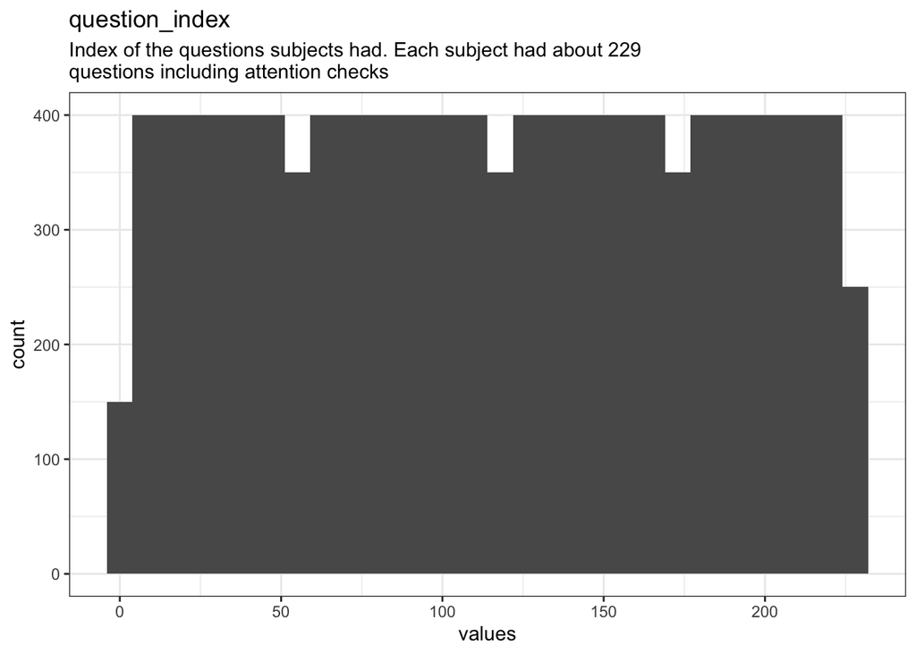

Distribution of values for question_index

750 missing values.

#### 1.1.5.2 Summary statistics

| name | label | data_type | n_missing | complete_rate | min | median | max | mean | sd | hist |
| --- | --- | --- | --- | --- | --- | --- | --- | --- | --- | --- |
| question_index | Index of the questions subjects had. Each subject had about 229 questions including attention checks | numeric | 750 | 0.9385246 | 1 | 115 | 229 | 115 | 66.10886 | ▇▇▇▇▇ |

### 1.1.6 response

Slider rating for the causal pairs. Values range from 0 to 100 with 0 being `definitely not` and 100 being `definitely yes`

#### 1.1.6.1 Distribution

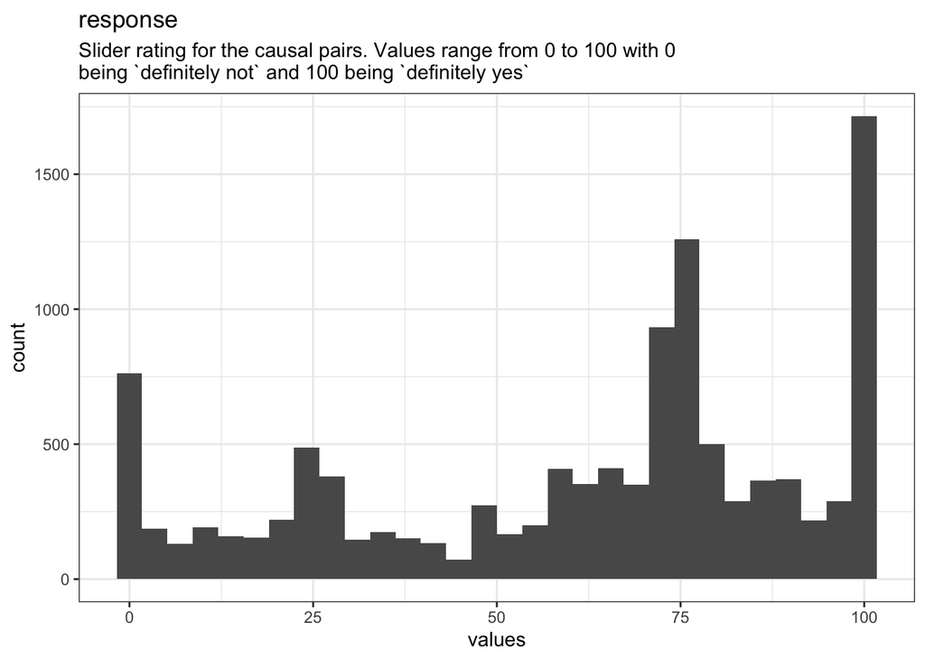

Distribution of values for response

750 missing values.

#### 1.1.6.2 Summary statistics

| name | label | data_type | n_missing | complete_rate | min | median | max | mean | sd | hist |
| --- | --- | --- | --- | --- | --- | --- | --- | --- | --- | --- |
| response | Slider rating for the causal pairs. Values range from 0 to 100 with 0 being `definitely not` and 100 being `definitely yes` | numeric | 750 | 0.9385246 | 0 | 72 | 100 | 61.24576 | 31.49831 | ▃▃▂▇▇ |

### 1.1.7 itemA

First item in the pairing in the Causal Task. This is the cause

#### 1.1.7.1 Distribution

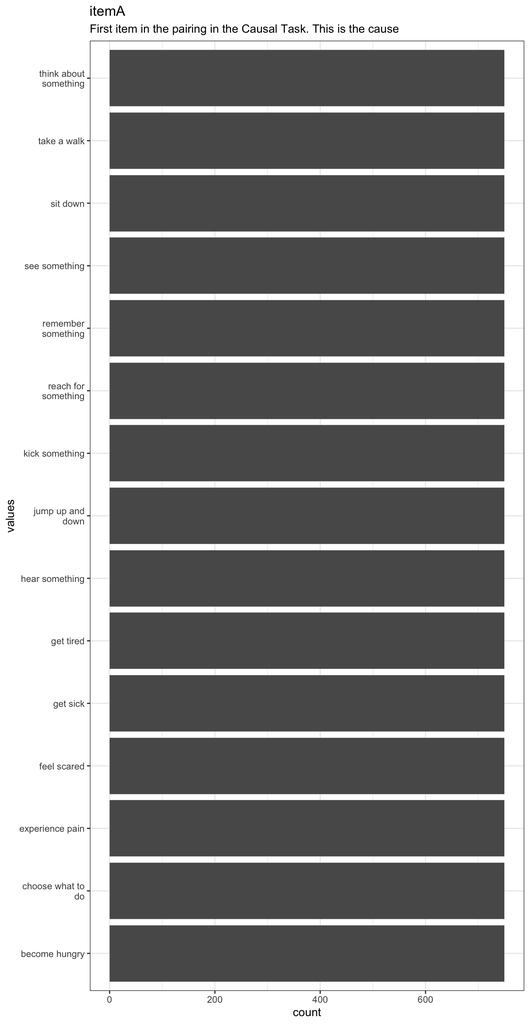

Distribution of values for itemA

950 missing values.

#### 1.1.7.2 Summary statistics

| name | label | data_type | ordered | value_labels | n_missing | complete_rate | n_unique | top_counts |
| --- | --- | --- | --- | --- | --- | --- | --- | --- |
| itemA | First item in the pairing in the Causal Task. This is the cause | factor | FALSE | 1. become hungry, 2. choose what to do, 3. experience pain, 4. feel scared, 5. get sick, 6. get tired, 7. hear something, 8. jump up and down, 9. kick something, 10. reach for something, 11. remember … | 950 | 0.9221311 | 15 | bec: 750, cho: 750, exp: 750, fee: 750 |

### 1.1.8 itemB

second item in the pairing in the Causal Task. This is the effect

#### 1.1.8.1 Distribution

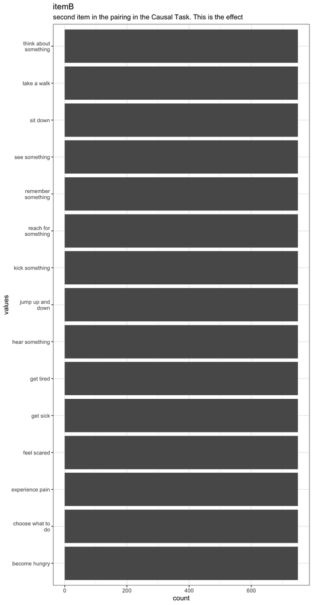

Distribution of values for itemB

950 missing values.

#### 1.1.8.2 Summary statistics

| name | label | data_type | ordered | value_labels | n_missing | complete_rate | n_unique | top_counts |
| --- | --- | --- | --- | --- | --- | --- | --- | --- |
| itemB | second item in the pairing in the Causal Task. This is the effect | factor | FALSE | 1. become hungry, 2. choose what to do, 3. experience pain, 4. feel scared, 5. get sick, 6. get tired, 7. hear something, 8. jump up and down, 9. kick something, 10. reach for something, 11. remember … | 950 | 0.9221311 | 15 | bec: 750, cho: 750, exp: 750, fee: 750 |

### 1.1.9 categoryA

A priori category (or domain) of itemA, or the first item

#### 1.1.9.1 Distribution

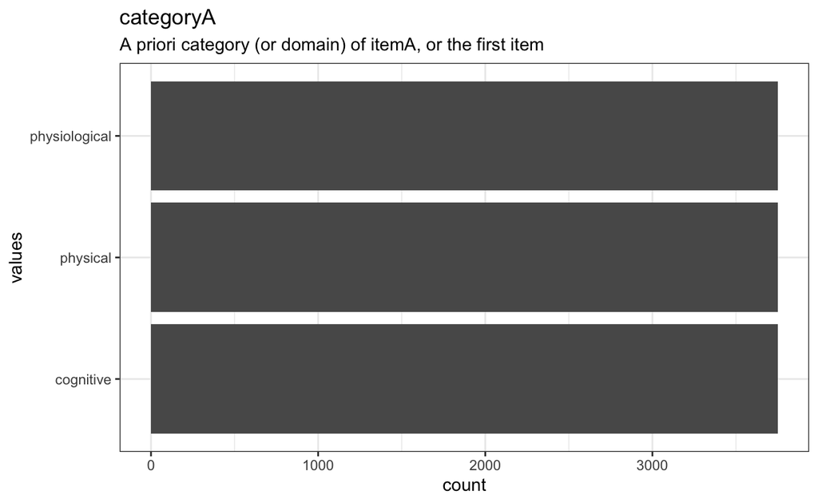

Distribution of values for categoryA

950 missing values.

#### 1.1.9.2 Summary statistics

| name | label | data_type | ordered | value_labels | n_missing | complete_rate | n_unique | top_counts |
| --- | --- | --- | --- | --- | --- | --- | --- | --- |
| categoryA | A priori category (or domain) of itemA, or the first item | factor | FALSE | 1. cognitive, 2. physical, 3. physiological | 950 | 0.9221311 | 3 | cog: 3750, phy: 3750, phy: 3750 |

### 1.1.10 categoryB

A priori category (or domain) of itemB, or the second item

#### 1.1.10.1 Distribution

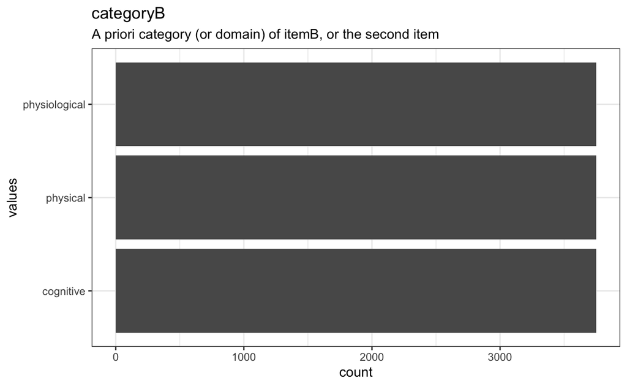

Distribution of values for categoryB

950 missing values.

#### 1.1.10.2 Summary statistics

| name | label | data_type | ordered | value_labels | n_missing | complete_rate | n_unique | top_counts |
| --- | --- | --- | --- | --- | --- | --- | --- | --- |
| categoryB | A priori category (or domain) of itemB, or the second item | factor | FALSE | 1. cognitive, 2. physical, 3. physiological | 950 | 0.9221311 | 3 | cog: 3750, phy: 3750, phy: 3750 |

### 1.1.11 attention_check

#### 1.1.11.1 Distribution

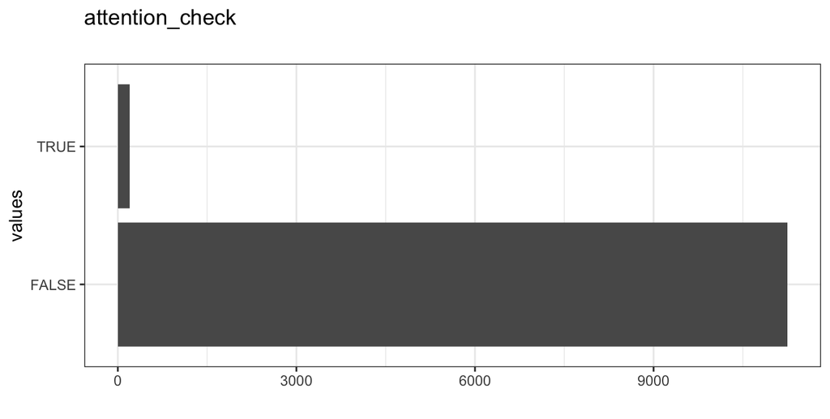

Distribution of values for attention_check

750 missing values.

#### 1.1.11.2 Summary statistics

| name | data_type | n_missing | complete_rate | count | mean | label |
| --- | --- | --- | --- | --- | --- | --- |
| attention_check | logical | 750 | 0.9385246 | FAL: 11250, TRU: 200 | 0.0174672 | NA |

### 1.1.12 correct_response

#### 1.1.12.1 Distribution

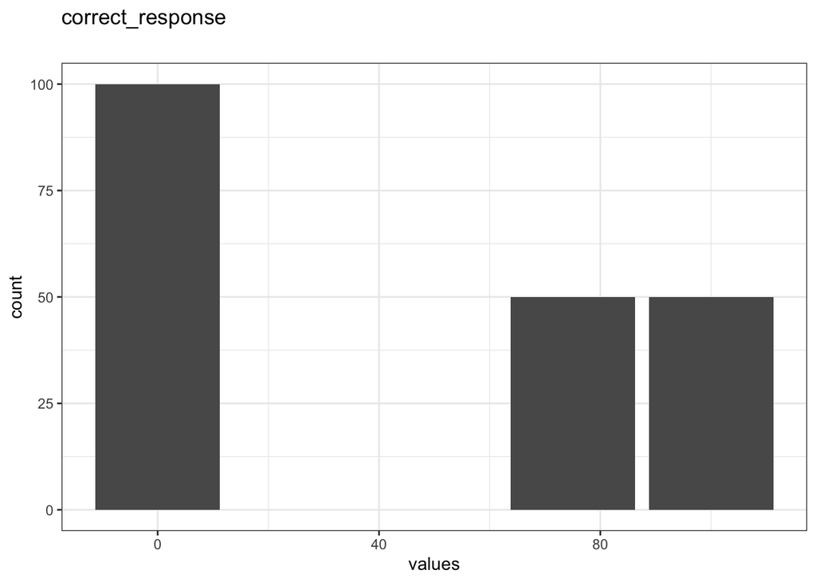

Distribution of values for correct_response

12000 missing values.

#### 1.1.12.2 Summary statistics

| name | data_type | n_missing | complete_rate | min | median | max | mean | sd | hist | label |
| --- | --- | --- | --- | --- | --- | --- | --- | --- | --- | --- |
| correct_response | numeric | 12000 | 0.0163934 | 0 | 38 | 100 | 43.75 | 44.74593 | ▇▁▁▃▃ | NA |

### 1.1.13 original_trial_index

Pre-transformed trial index before running pre-processing script

#### 1.1.13.1 Distribution

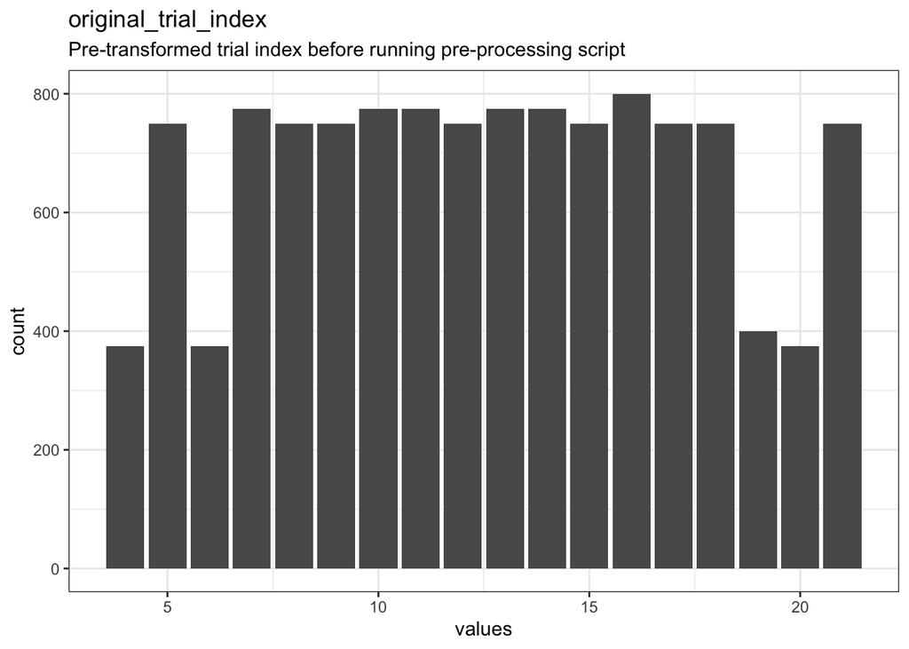

Distribution of values for original_trial_index

0 missing values.

#### 1.1.13.2 Summary statistics

| name | label | data_type | n_missing | complete_rate | min | median | max | mean | sd | hist |
| --- | --- | --- | --- | --- | --- | --- | --- | --- | --- | --- |
| original_trial_index | Pre-transformed trial index before running pre-processing script | numeric | 0 | 1 | 4 | 13 | 21 | 12.54303 | 4.843458 | ▆▆▇▆▆ |

### 1.1.14 original_question_index

Pre-transformed question index before running pre-processing script

#### 1.1.14.1 Distribution

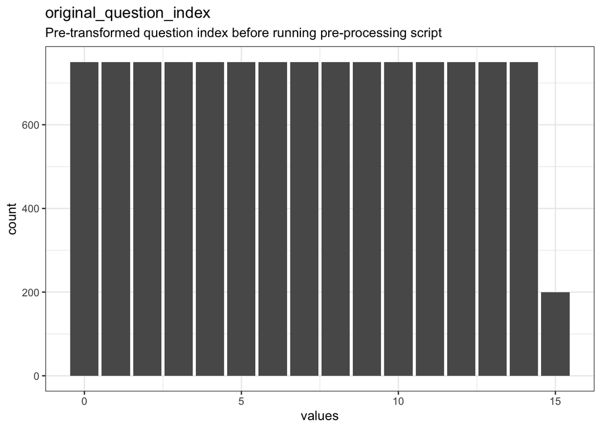

Distribution of values for original_question_index

750 missing values.

#### 1.1.14.2 Summary statistics

| name | label | data_type | n_missing | complete_rate | min | median | max | mean | sd | hist |
| --- | --- | --- | --- | --- | --- | --- | --- | --- | --- | --- |
| original_question_index | Pre-transformed question index before running pre-processing script | numeric | 750 | 0.9385246 | 0 | 7 | 15 | 7.139738 | 4.409159 | ▇▆▆▆▅ |

### 1.1.15 attention_check_id

value showing id of the attention check question, it was one of four ids

#### 1.1.15.1 Distribution

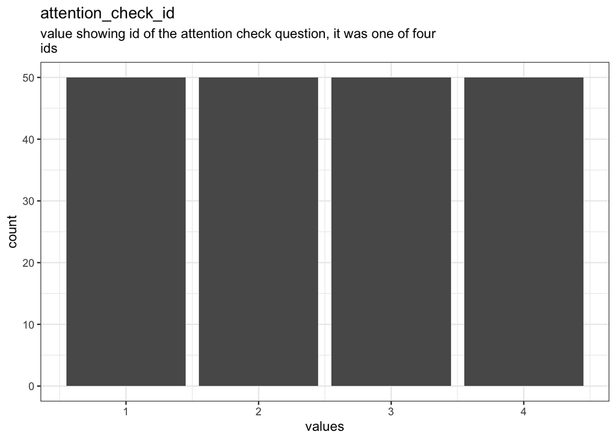

Distribution of values for attention_check_id

12000 missing values.

#### 1.1.15.2 Summary statistics

| name | label | data_type | n_missing | complete_rate | min | median | max | mean | sd | hist |
| --- | --- | --- | --- | --- | --- | --- | --- | --- | --- | --- |
| attention_check_id | value showing id of the attention check question, it was one of four ids | numeric | 12000 | 0.0163934 | 1 | 2.5 | 4 | 2.5 | 1.12084 | ▇▇▁▇▇ |

### 1.1.16 correct

Indicates if attention check question was correct based on predefined answer

#### 1.1.16.1 Distribution

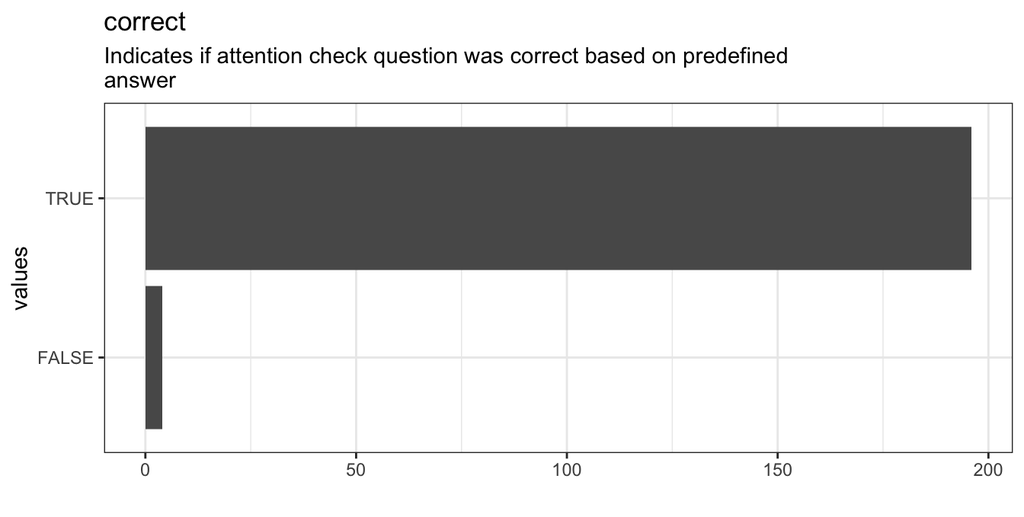

Distribution of values for correct

12000 missing values.

#### 1.1.16.2 Summary statistics

| name | label | data_type | n_missing | complete_rate | count | mean |
| --- | --- | --- | --- | --- | --- | --- |
| correct | Indicates if attention check question was correct based on predefined answer | logical | 12000 | 0.0163934 | TRU: 196, FAL: 4 | 0.98 |

### 1.1.17 x

x coordinate of item in the sorting canvas for the Sorting Task

#### 1.1.17.1 Distribution

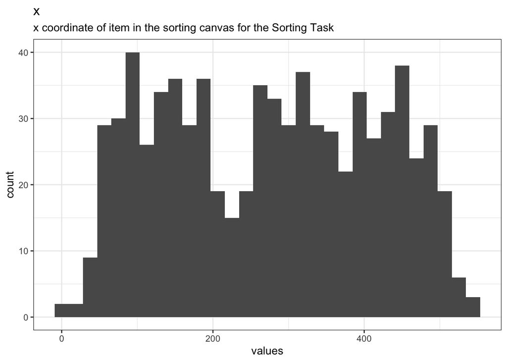

Distribution of values for x

11450 missing values.

#### 1.1.17.2 Summary statistics

| name | label | data_type | n_missing | complete_rate | min | median | max | mean | sd | hist |
| --- | --- | --- | --- | --- | --- | --- | --- | --- | --- | --- |
| x | x coordinate of item in the sorting canvas for the Sorting Task | numeric | 11450 | 0.0614754 | 1 | 279 | 545 | 275.3907 | 140.457 | ▆▇▇▇▆ |

### 1.1.18 y

y coordinate of item in the sorting canvas for the Sorting Task

#### 1.1.18.1 Distribution

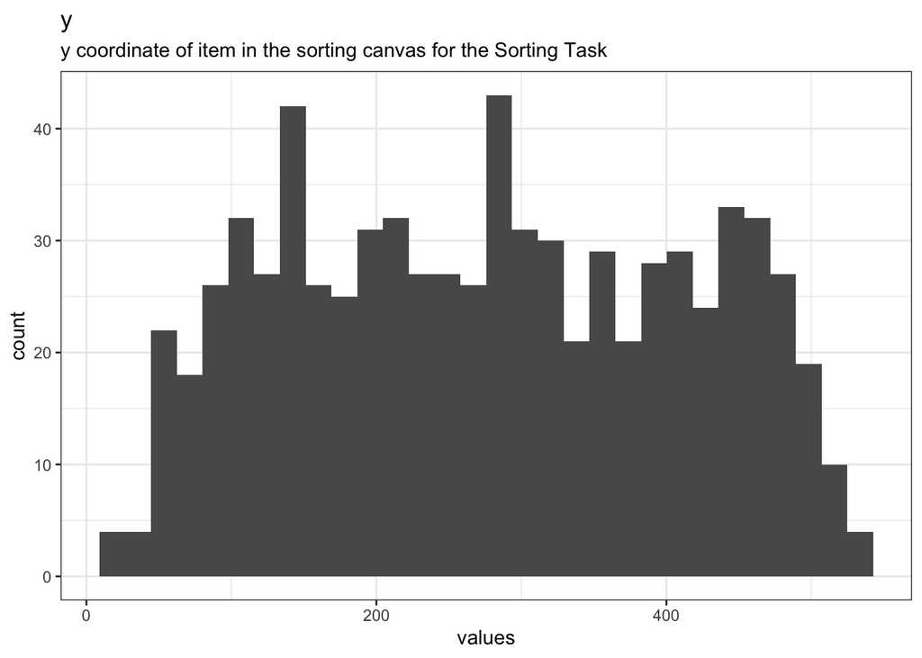

Distribution of values for y

11450 missing values.

#### 1.1.18.2 Summary statistics

| name | label | data_type | n_missing | complete_rate | min | median | max | mean | sd | hist |
| --- | --- | --- | --- | --- | --- | --- | --- | --- | --- | --- |
| y | y coordinate of item in the sorting canvas for the Sorting Task | numeric | 11450 | 0.0614754 | 18 | 277 | 534 | 277.568 | 134.3142 | ▅▇▇▇▆ |

### 1.1.19 item

item ID in Sorting Task

#### 1.1.19.1 Distribution

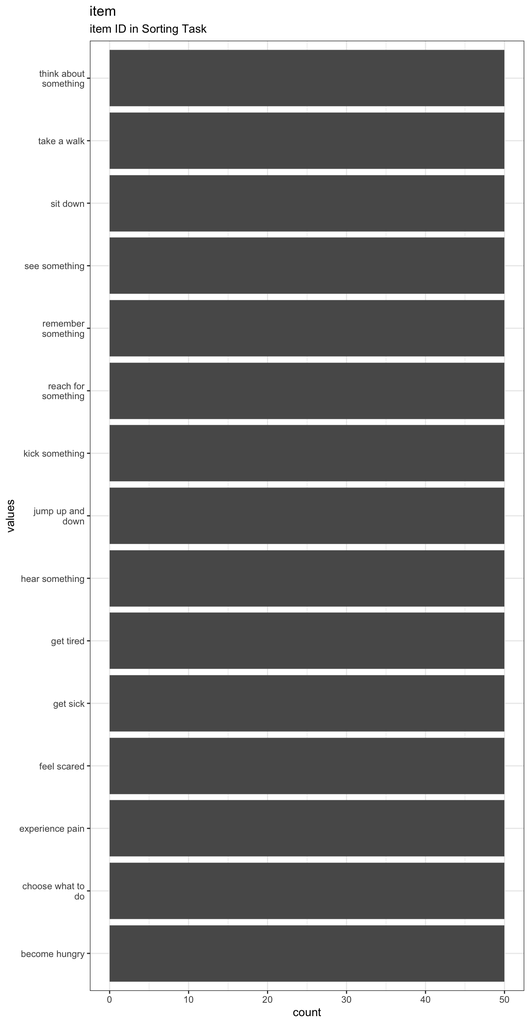

Distribution of values for item

11450 missing values.

#### 1.1.19.2 Summary statistics

| name | label | data_type | n_missing | complete_rate | n_unique | empty | min | max | whitespace |
| --- | --- | --- | --- | --- | --- | --- | --- | --- | --- |
| item | item ID in Sorting Task | character | 11450 | 0.0614754 | 15 | 0 | 8 | 21 | 0 |

## 1.2 Missingness report

| description | trial_index | question_index | response | attention_check | original_question_index | itemA | itemB | categoryA | categoryB | x | y | item | correct_response | attention_check_id | correct | var_miss | n_miss |
| --- | --- | --- | --- | --- | --- | --- | --- | --- | --- | --- | --- | --- | --- | --- | --- | --- | --- |
| Missing values per variable | 750 | 750 | 750 | 750 | 750 | 950 | 950 | 950 | 950 | 11450 | 11450 | 11450 | 12000 | 12000 | 12000 | 77900 | 77900 |
| Missing values in 6 variables | 1 | 1 | 1 | 1 | 1 | 1 | 1 | 1 | 1 | 0 | 0 | 0 | 0 | 0 | 0 | 6 | 11250 |
| Missing values in 12 variables | 0 | 0 | 0 | 0 | 0 | 0 | 0 | 0 | 0 | 1 | 1 | 1 | 0 | 0 | 0 | 12 | 750 |
| Missing values in 7 variables | 1 | 1 | 1 | 1 | 1 | 0 | 0 | 0 | 0 | 0 | 0 | 0 | 1 | 1 | 1 | 7 | 200 |

## 1.3 Codebook table

| name | label | data_type | ordered | value_labels | n_missing | complete_rate | n_unique | empty | top_counts | count | min | median | max | mean | sd | whitespace | hist |
| --- | --- | --- | --- | --- | --- | --- | --- | --- | --- | --- | --- | --- | --- | --- | --- | --- | --- |
| subject_id | Subject ids for all 50 subjects | factor | FALSE | 1. subj_01, 2. subj_02, 3. subj_03, 4. subj_04, 5. subj_05, 6. subj_06, 7. subj_07, 8. subj_08, 9. subj_09, 10. subj_10, 11. subj_11, 12. subj_12, 13. subj_13, 14. subj_14, 15. subj_15, 16. subj_16, 1… | 0 | 1.0000000 | 50 | NA | sub: 244, sub: 244, sub: 244, sub: 244 | NA | NA | NA | NA | NA | NA | NA | NA |
| trial_type | Factor showing the two experimental conditions: Causal Task vs Sorting Task | factor | FALSE | 1. causation, 2. free_sort | 0 | 1.0000000 | 2 | NA | cau: 11450, fre: 750 | NA | NA | NA | NA | NA | NA | NA | NA |
| trial_type_order | Factor showing the two experimental orders, Causal Task first or Sorting Task first | factor | FALSE | 1. first, 2. second | 0 | 1.0000000 | 2 | NA | fir: 6100, sec: 6100 | NA | NA | NA | NA | NA | NA | NA | NA |
| trial_index | Index indicating the page of the trial. Subjects had about 15 pages of trials | numeric | NA | NA | 750 | 0.9385246 | NA | NA | NA | NA | 1 | 8.0 | 15 | 8.0131004 | 4.305643 | NA | ▇▇▇▇▇ |
| question_index | Index of the questions subjects had. Each subject had about 229 questions including attention checks | numeric | NA | NA | 750 | 0.9385246 | NA | NA | NA | NA | 1 | 115.0 | 229 | 115.0000000 | 66.108862 | NA | ▇▇▇▇▇ |
| response | Slider rating for the causal pairs. Values range from 0 to 100 with 0 being `definitely not` and 100 being `definitely yes` | numeric | NA | NA | 750 | 0.9385246 | NA | NA | NA | NA | 0 | 72.0 | 100 | 61.2457642 | 31.498311 | NA | ▃▃▂▇▇ |
| itemA | First item in the pairing in the Causal Task. This is the cause | factor | FALSE | 1. become hungry, 2. choose what to do, 3. experience pain, 4. feel scared, 5. get sick, 6. get tired, 7. hear something, 8. jump up and down, 9. kick something, 10. reach for something, 11. remember … | 950 | 0.9221311 | 15 | NA | bec: 750, cho: 750, exp: 750, fee: 750 | NA | NA | NA | NA | NA | NA | NA | NA |
| itemB | second item in the pairing in the Causal Task. This is the effect | factor | FALSE | 1. become hungry, 2. choose what to do, 3. experience pain, 4. feel scared, 5. get sick, 6. get tired, 7. hear something, 8. jump up and down, 9. kick something, 10. reach for something, 11. remember … | 950 | 0.9221311 | 15 | NA | bec: 750, cho: 750, exp: 750, fee: 750 | NA | NA | NA | NA | NA | NA | NA | NA |
| categoryA | A priori category (or domain) of itemA, or the first item | factor | FALSE | 1. cognitive, 2. physical, 3. physiological | 950 | 0.9221311 | 3 | NA | cog: 3750, phy: 3750, phy: 3750 | NA | NA | NA | NA | NA | NA | NA | NA |
| categoryB | A priori category (or domain) of itemB, or the second item | factor | FALSE | 1. cognitive, 2. physical, 3. physiological | 950 | 0.9221311 | 3 | NA | cog: 3750, phy: 3750, phy: 3750 | NA | NA | NA | NA | NA | NA | NA | NA |
| attention_check | NA | logical | NA | NA | 750 | 0.9385246 | NA | NA | NA | FAL: 11250, TRU: 200 | NA | NA | NA | 0.0174672 | NA | NA | NA |
| correct_response | NA | numeric | NA | NA | 12000 | 0.0163934 | NA | NA | NA | NA | 0 | 37.5 | 100 | 43.7500000 | 44.745933 | NA | ▇▁▁▃▃ |
| original_trial_index | Pre-transformed trial index before running pre-processing script | numeric | NA | NA | 0 | 1.0000000 | NA | NA | NA | NA | 4 | 13.0 | 21 | 12.5430328 | 4.843458 | NA | ▆▆▇▆▆ |
| original_question_index | Pre-transformed question index before running pre-processing script | numeric | NA | NA | 750 | 0.9385246 | NA | NA | NA | NA | 0 | 7.0 | 15 | 7.1397380 | 4.409159 | NA | ▇▆▆▆▅ |
| attention_check_id | value showing id of the attention check question, it was one of four ids | numeric | NA | NA | 12000 | 0.0163934 | NA | NA | NA | NA | 1 | 2.5 | 4 | 2.5000000 | 1.120840 | NA | ▇▇▁▇▇ |
| correct | Indicates if attention check question was correct based on predefined answer | logical | NA | NA | 12000 | 0.0163934 | NA | NA | NA | TRU: 196, FAL: 4 | NA | NA | NA | 0.9800000 | NA | NA | NA |
| x | x coordinate of item in the sorting canvas for the Sorting Task | numeric | NA | NA | 11450 | 0.0614754 | NA | NA | NA | NA | 1 | 279.0 | 545 | 275.3906667 | 140.457048 | NA | ▆▇▇▇▆ |
| y | y coordinate of item in the sorting canvas for the Sorting Task | numeric | NA | NA | 11450 | 0.0614754 | NA | NA | NA | NA | 18 | 277.0 | 534 | 277.5680000 | 134.314190 | NA | ▅▇▇▇▆ |
| item | item ID in Sorting Task | character | NA | NA | 11450 | 0.0614754 | 15 | 0 | NA | NA | 8 | NA | 21 | NA | NA | 0 | NA |